# Lab 01

Giancarlo M. Correa

This is a *brief* summary of the concepts discussed in this course.

First, we need these packages:

```r
require(dplyr)
require(splitstackshape)
```

# 1 Sampling methods

We simulate sizes of a population (1900 individuals) at different ages.

```r
group1 = expand.grid(size = rnorm(n = 1000, mean = 30, sd = 4),
                     age = 4) # 1000 ind age 4
group2 = expand.grid(size = rnorm(n = 600, mean = 40, sd = 5),
                     age = 5) # 600 ind age 5
group3 = expand.grid(size = rnorm(n = 300, mean = 55, sd = 6),
                     age = 6) # 300 ind age 6
popdata = rbind(group1, group2, group3)
popdata = popdata[sample(x = 1:1900, size = 1900, replace = F), ]
row.names(popdata) = 1:1900
```

`popdata` is the object that contains the population information. We plot all the sizes:

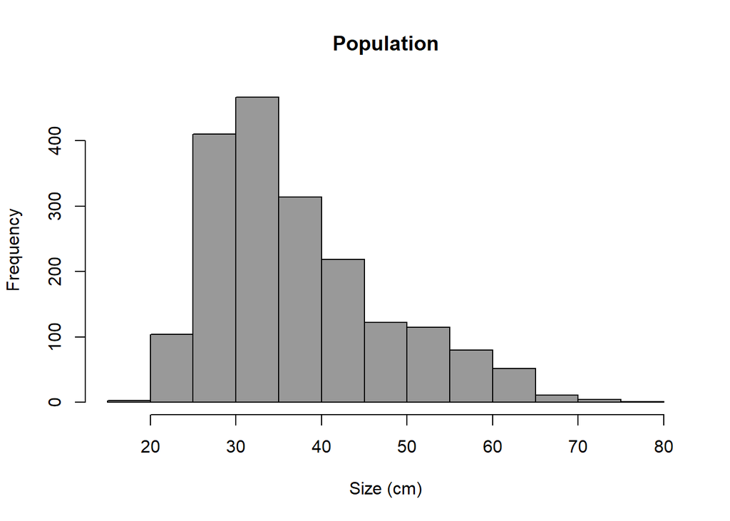

```r
hist(x = popdata$size, xlab = 'Size (cm)', main = 'Population',
     col = 'gray60')
```

## 1.1 Random sampling

Each individual in the population has the same probability to be sampled (independent). We take a random sampling (180 individuals) from the simulated population:

```r
n_samp = 180 # number of individuals sampled
random_samp = sample_n(tbl = popdata, size = n_samp)
```

## 1.2 Systematic sampling

A defined pattern is followed to sample the population. We take a systematic sampling from the simulated population.

```r
start_num = sample(x = 1:10, size = 1) # initial number to start the sampling process
ind_sampled = seq(from = start_num, to = nrow(popdata), length.out = n_samp) # 180 ind sampled
ind_sampled = round(ind_sampled)
system_samp = popdata[ind_sampled, ] # this is the sampling
```

## 1.3 Stratified sampling

The population to be sampled is divided in strata, and then random samples are taken from each stratum. We take a stratified sampling from the simulated population.

```r
strat_samp = stratified(indt = popdata, group = 'age', size = 60) # 60 ind sampled by age
```

Now, we can calculate some statistics from the samples and compare them with the true value in the population. For example, we calculate the mean size:

```r
abs(mean(random_samp$size) - mean(popdata$size)) # random
```

```
## [1] 0.894068
```

```r
abs(mean(system_samp$size) - mean(popdata$size)) # systematic
```

```
## [1] 0.05886516
```

```r
abs(mean(strat_samp$size) - mean(popdata$size)) # stratified
```

```
## [1] 4.239336
```

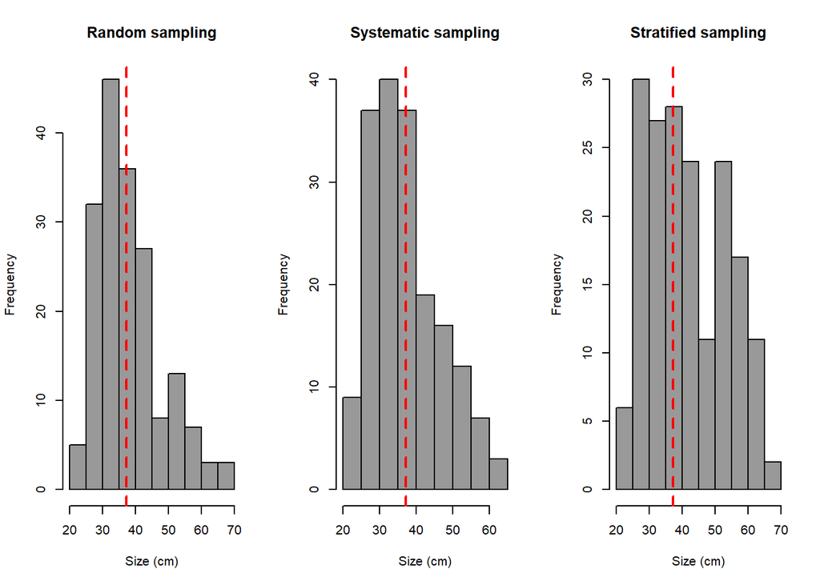

```r
# Plot:
par(mfrow = c(1,3))
hist(random_samp$size, xlab = 'Size (cm)', main = 'Random sampling',
     col = 'gray60')
abline(v = mean(popdata$size), col = 'red', lty = 2, lwd = 2)
hist(system_samp$size, xlab = 'Size (cm)', main = 'Systematic sampling',
     col = 'gray60')
abline(v = mean(popdata$size), col = 'red', lty = 2, lwd = 2)
hist(strat_samp$size, xlab = 'Size (cm)', main = 'Stratified sampling',
     col = 'gray60')
abline(v = mean(popdata$size), col = 'red', lty = 2, lwd = 2)
```

# 2 Bases estadísticas

Revisamos los conceptos básicos de estadística empleados en este curso.

## 2.1 Tipos de variables

Una variable es un atributo que describe un individuo, lugar o cosa. Este atributo claramente puede variar entre individuos. Por nombrar algunos ejemplos: altura total, longitud, temperatura, edad, sexo, etc. Las variables pueden ser clasificadas como sigue:

### 2.1.1 Variable cuantitativa

Refleja algún tipo de magnitud, representa una medida y es numérica. Esta puede ser divida en:

- *Discreta*: Valores que toma la variable son contables y tienen un número finito de posibilidades. Ejemplo: Número de individuos, número de especies.
- *Continua*: Valores no son contables y tienen un infinito número de posibilidades. Ejemplo: temperatura, altura, peso.

### 2.1.2 Variable cualitativa

No son numéricas, los valores que toman son categorías.

- *Nominal*: No existe un orden para los diferentes niveles de la variable. Ejemplo: sexo, color de pelaje, presencia/ausencia.
- *Ordinal*: Existe un orden para los niveles. Ejemplo: Nivel de daño, estadio de vida, edades.

Una variable se puede transformar, lo cual normalmente se hace para adaptarla a ciertos análisis estadísticos. Por ejemplo, es normal transformar una variable continua a discreta para ciertos propósitos (e.g. longitud continua a longitud en intervalos definidos). También de cuantitativa a cualitativa (e.g. transformar datos de abundancia a presencia/ausencia).

## 2.2 Estadísticos descriptivos

### 2.2.1 Tendencia central

Ofrecen una idea del centro de los datos.

1. *Media*: Representado por $\bar{x}$, idea del valor central de los datos. Puede ser sensible a outliers. Estimado como:

$\bar{x} = \frac{1}{n}\sum_i x_i$

Donde $n$ es el número de individuos muestreados y $x_i$ es el valor de la variable para el individuos $i$.

2. *Mediana*: Observación que divide a la muestra en dos partes iguales.
3. *Primer cuartil*: Observación que divide a la muestra en dos partes: 25% inferior y 75% superior.
4. *Tercer cuartil*: Observación que divide a la muestra en dos partes: 75% inferior y 25% superior.
5. *Moda*: Valor que aparece con mayor frecuencia en las observaciones. Puede haber más de una moda (multimodal).

### 2.2.2 Dispersión

1. *Rango*: Diferencia entre el valor máximo y mínimo en las observaciones.
2. *Desviación estándar*: Desviación de los datos con respecto a la media. Se estima:

$s=\sqrt{\frac{1}{n}\sum_i (x_i-\bar{x})^2}$

3. *Varianza*: Es $s$ elevado al cuadrado.
4. *Rango intercuartil*: Diferencia entre el tercer y primer cuartil.
5. *Coeficiente de variación*: División entre $s$ y $\bar{x}$. Se emplea cuando se quiere comparar la dispersión entre dos variables con diferentes unidades.

## 2.3 Probabilidades

Definimos algunos conceptos importantes:

1. *Espacio muestral*: conjunto de todos los posibles resultados de un experimento.
2. *Evento*: conjunto de resultados que son de interés para un estudio.
3. *Probabilidad de un evento*: frecuencia relativa del conjunto de resultados de interés.
4. *Variable aleatoria*: función que asigna valores numéricos a diferentes eventos en un espacio muestral.
5. *Distribución de probabilidad*: asigna cierta probabilidad a un evento determinado $Pr(X=r)$, donde $X$ representa a una variable aleatoria.

Existen una serie de distribuciones de probabilidad. Vamos a detallar tres: normal, binomial, y Poisson.

### 2.3.1 Distribución normal

Función de probabilidad es:

$f(x)=\frac{1}{\sqrt{2\pi\sigma}}\exp[-\frac{1}{2\sigma^2}(x-\mu)^2]$

donde $-\infty <x<\infty$, y $\sigma$ y $\mu$ representan la desviación estándar y la media de la población. Esta distribución es normalmente referida como $N(\mu, \sigma^2)$. Utilizada para datos continuos.

*Ejemplo:* Asumamos que la altura de una especie sigue una distribucion normal. Observamos en una muestra que la media es 72 mm y la desviacion estandar es 15.2 mm. Cual es el porcentaje de individuos que tiene mas de 84 mm.

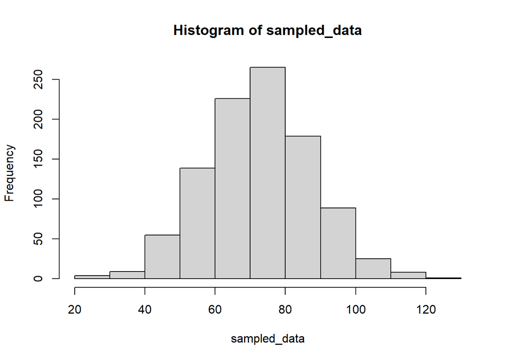

```r
# Simulemos datos con distribucion normal
sampled_data = rnorm(n = 1000, mean = 72, sd = 15.2)
hist(sampled_data)
```

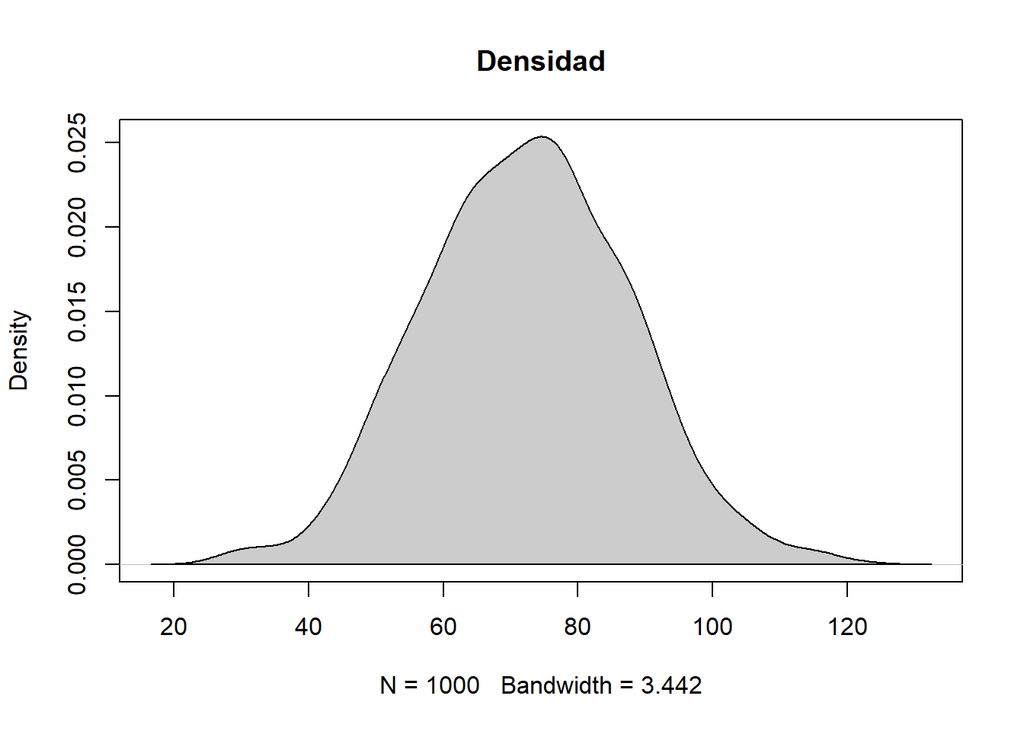

```r
# Graficar en forma de densidad:
dens = density(sampled_data)
plot(dens, main="Densidad")
polygon(dens, col="gray80")
```

```r
# Calculemos la proporcion (probabilidad)
1 - pnorm(q = 84, mean = 72, sd = 15.2)
```

```
## [1] 0.2149176
```

```r
pnorm(q = 84, mean=72, sd=15.2, lower.tail = FALSE)
```

```
## [1] 0.2149176
```

```r
# Podemos tambien encontrar la probabilidad exacta para
# un valor de altura dado:
dnorm(x = 84, mean = 72, sd = 15.2)
```

```
## [1] 0.01921876
```

### 2.3.2 Distribución binomial

Función de probabilidad es:

$Pr(X=k)= {n \choose k}p^k(1-p)^{n-k}$

donde $k=0,1,2,...,n$. Aquí, $n$ representa el número de intentos independientes de algún evento, y $p$ es la probabilidad de éxito.

```r
# Simulamos los datos:
n_sim = 50
sim_data = rbinom(n = 1, size = n_sim, prob = 0.5)
sim_data # obs probabilidad
```

```
## [1] 27
```

```r
# Calculemos la probabilidad (asumimos p = 0.5):
pbinom(q = 20, size = n_sim, prob = 0.5)
```

```
## [1] 0.1013194
```

```r
# Podemos tambien encontrar la probabilidad exacta:
dbinom(x = 20, size = n_sim, prob = 0.5)
```

```
## [1] 0.04185915
```

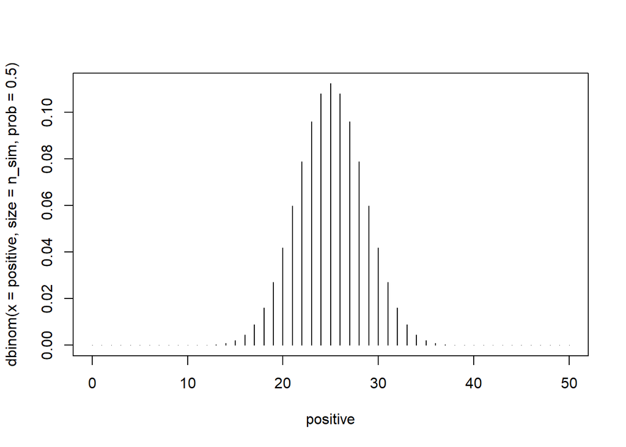

```r
# Grafiquemos todas las opciones:
positive = 0:50
plot(positive, dbinom(x = positive, size = n_sim, prob = 0.5), type = 'h')
```

### 2.3.3 Distribución Poisson

Para estudiar la probabilidad de $k$ eventos que ocurren en un periodo de tiempo $t$ (representado por $\lambda$). También puede asumirse por unidad de espacio (e.g. estación de muestreo). La función de probabilidad es:

$Pr(X=k)=e^{-\mu}\frac{\mu^k}{k!}$

Donde $k=0,1,2,...$. $\mu=\lambda t$.

*Ejemplo:* Tenemos un muestreo aleatorio (estaciones) y observamos el numero de individuos por estacion de una especie dada. La distribucion es tipo Poisson con $\lambda=15$ (ind/estacion). Calcular la probabilidad de encontrar mas de 20 individuos en una estacion de muestreo.

```r
# Simulamos nuestros datos:
n_sim = 50
sim_data = rpois(n = n_sim, lambda = 15)
length(which(sim_data>20))/n_sim # obs probabilidad
```

```
## [1] 0.12
```

```r
# Calculemos la probabilidad:
1 - ppois(q = 20, lambda = 15)
```

```
## [1] 0.08297091
```

```r
ppois(q = 20, lambda = 15, lower.tail = FALSE)
```

```
## [1] 0.08297091
```

```r
# Podemos tambien encontrar la probabilidad exacta (de encontrar 20 ind en una estacion):
dpois(x = 20, lambda = 15)
```

```
## [1] 0.04181031
```